# Worksheet D

#### *variationalform* https://variationalform.github.io/

#### *Just Enough: progress at pace*

https://variationalform.github.io/

https://github.com/variationalform

Simon Shaw https://www.brunel.ac.uk/people/simon-shaw.

|  | This work is licensed under CC BY-SA 4.0 (Attribution-ShareAlike 4.0 International) Visit http://creativecommons.org/licenses/by-sa/4.0/ to see the terms. |
| --- | --- |

| This document uses python |  | and also makes use of LaTeX |  | in Markdown |  |
| --- | --- | --- | --- | --- | --- |

## What this is about:

This worksheet is based on the material in the notebook

- regress: polynomial and logistic regression.

Note that while the 'lecture' notebooks are prefixed with `1_`, `2_` and so on, to indicate the order in which they should be studied, the worksheets are prefixed with `A_`, `B_`, ...

```python
# useful imports
import numpy as np
import seaborn as sns
import matplotlib.pyplot as plt
from sklearn import linear_model
```

### Exercise 1

A straight line has gradient $m=2$ and $y$-intercept $c=4$. Sketch it, and determine the value of $x$ for which $y=8$.

```python
# Answer here - create more cells as necessary
```

### Exercise 2

A straight line with gradient $m$ passes though the point $(x_0,y_0)$. Show that $y-y_0 = m(x-x_0)$. This is called the *point slope* form.

```python
# Answer here - create more cells as necessary
```

### Exercise 3

A line with gradient $m=5$ passes through $(x,y)=(-1,2)$. Find the equation of the line in the form $y=mx+c$.

```python
# Answer here - create more cells as necessary
```

### Exercise 4

Recall Anscombe's data set. We used the following code to split it into its four sub-sets, and we also produced scatterplots, as shown below for the first data subset.

```
dfa = sns.load_dataset('anscombe')
print("The size of Anscombe's data set is:", dfa.shape)
dfa.dataset.unique()
dfa1 = dfa.loc[dfa['dataset'] == 'I']
dfa2 = dfa.loc[dfa['dataset'] == 'II']
dfa3 = dfa.loc[dfa['dataset'] == 'III']
dfa4 = dfa.loc[dfa['dataset'] == 'IV']
sns.scatterplot(data=dfa1, x="x", y="y")
dfa1.describe()
```

Implement linear regression for this fist dataset `dfa1`. Then implement ridge and LASSO regression. Plot your regreesion lines on the same plot and include the underlying data.

You might find the following useful:

```
dfreg = dfa1.sort_values('x', ascending = True).reset_index(drop=True)
```

After this you can either reassign `dfa1 = dfreg` or work directly with `dfreg`.

### Exercise 5

Repeat Exercise 4 but with `dfa2`.

### Exercise 6

Repeat Exercise 5 but with `dfa3`.

### Exercise 7

Repeat Exercise 6 but with `dfa4`.

# Outline Suggested Solutions

The following are suggestions for solutions of the above problems. Please have a go first though before looking at these.

### Solution 1

The line passes through the vertical axis at $y=4$ and climbs a vertical distance of $2$ for every unit of horizontal distance. When $y=8$, we have from $y=mx+c$ that $x=(y-c)/m = 2$.

### Solution 2

At another (arbitrary but distinct) point $(x,y)$ the gradient is $m = (y-y_0)/(x-x_0)$. The *point slope* form follows.

### Solution 3

$y-y_0 = m(x-x_0)$ with $(x_0,y_0)=(-1,2)$ and $m=5$. Therefore

$$ y = mx - mx_0 + y_0 = 5x -(5\times-1-2) = 5x+7. $$

### Solution 4

An outline solution to Exercise 4 follows.

```python
dfa = sns.load_dataset('anscombe')
print("The size of Anscombe's data set is:", dfa.shape)
```

```
The size of Anscombe's data set is: (44, 3)
```

```python
dfa.dataset.unique()
```

```
array(['I', 'II', 'III', 'IV'], dtype=object)
```

```python
dfa1 = dfa.loc[dfa['dataset'] == 'I']
dfa2 = dfa.loc[dfa['dataset'] == 'II']
dfa3 = dfa.loc[dfa['dataset'] == 'III']
dfa4 = dfa.loc[dfa['dataset'] == 'IV']
```

|  | x | y |
| --- | --- | --- |
| count | 11.000000 | 11.000000 |
| mean | 9.000000 | 7.500909 |
| std | 3.316625 | 2.031568 |
| min | 4.000000 | 4.260000 |
| 25% | 6.500000 | 6.315000 |
| 50% | 9.000000 | 7.580000 |
| 75% | 11.500000 | 8.570000 |
| max | 14.000000 | 10.840000 |

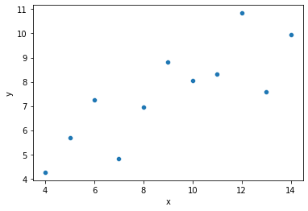

```python
sns.scatterplot(data=dfa1, x="x", y="y")
dfa1.describe()
```

```python
dfa1.head()
```

|  | dataset | x | y |
| --- | --- | --- | --- |
| 0 | I | 10.0 | 8.04 |
| 1 | I | 8.0 | 6.95 |
| 2 | I | 13.0 | 7.58 |
| 3 | I | 9.0 | 8.81 |
| 4 | I | 11.0 | 8.33 |

```python
dfreg = dfa1.sort_values('x', ascending = True).reset_index(drop=True)
```

```python
dfreg.head()
```

|  | dataset | x | y |
| --- | --- | --- | --- |
| 0 | I | 4.0 | 4.26 |
| 1 | I | 5.0 | 5.68 |
| 2 | I | 6.0 | 7.24 |
| 3 | I | 7.0 | 4.82 |
| 4 | I | 8.0 | 6.95 |

```python
X_vals = dfreg.iloc[:,1].values.reshape(-1,1)
y_vals = dfreg.iloc[:,2].values.reshape(-1,1)
#print(X_vals,'\n', y_vals)
```

```python
# standard (usual) regression
reg_usual = linear_model.LinearRegression()
reg_usual.fit(X_vals, y_vals)
# Make predictions
y_pred_usual = reg_usual.predict(X_vals)
print('reg_usual_coef_ = ', reg_usual.coef_)
print('reg_usual_intercept_ = ', reg_usual.intercept_)
```

```
reg_usual_coef_ =  [[0.50009091]]
reg_usual_intercept_ =  [3.00009091]
```

```python
# ridge regression
reg_ridge = linear_model.Ridge(alpha=0.5)
reg_ridge.fit(X_vals, y_vals)
# Make predictions
y_pred_ridge = reg_ridge.predict(X_vals)
print('reg_ridge_coef_ = ', reg_ridge.coef_)
print('reg_ridge_intercept_ = ', reg_ridge.intercept_)
```

```
reg_ridge_coef_ =  [[0.49782805]]
reg_ridge_intercept_ =  [3.0204566]
```

```python
# LASSO regression
reg_lasso = linear_model.Lasso(alpha=0.5)
reg_lasso.fit(X_vals, y_vals)
# Make predictions
y_pred_lasso = reg_lasso.predict(X_vals)
print('reg_lasso_coef_ = ', reg_lasso.coef_)
print('reg_lasso_intercept_ = ', reg_lasso.intercept_)
```

```
reg_lasso_coef_ =  [0.45009091]
reg_lasso_intercept_ =  [3.45009091]
```

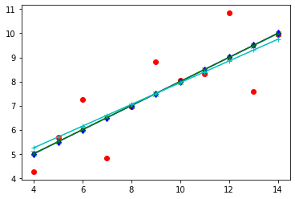

```python
plt.plot(X_vals,y_vals,'.r',marker='o')
plt.plot(X_vals,y_pred_usual,'b',marker='d')
plt.plot(X_vals,y_pred_ridge,'g',marker='x')
plt.plot(X_vals,y_pred_lasso,'c',marker='+')
```

### Solution 5

An outline solution to Exercise 5 follows.

```
reg_usual_coef_ =  [[0.5]]
reg_usual_intercept_ =  [3.00090909]
reg_ridge_coef_ =  [[0.49773756]]
reg_ridge_intercept_ =  [3.02127108]
reg_lasso_coef_ =  [0.45]
reg_lasso_intercept_ =  [3.45090909]
```

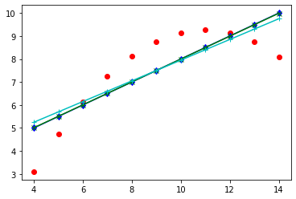

```python
dfreg = dfa2.sort_values('x', ascending = True).reset_index(drop=True)
X_vals = dfreg.iloc[:,1].values.reshape(-1,1)
y_vals = dfreg.iloc[:,2].values.reshape(-1,1)

# standard (usual) regression
reg_usual = linear_model.LinearRegression()
reg_usual.fit(X_vals, y_vals)
# Make predictions
y_pred_usual = reg_usual.predict(X_vals)
print('reg_usual_coef_ = ', reg_usual.coef_)
print('reg_usual_intercept_ = ', reg_usual.intercept_)

# ridge regression
reg_ridge = linear_model.Ridge(alpha=0.5)
reg_ridge.fit(X_vals, y_vals)
# Make predictions
y_pred_ridge = reg_ridge.predict(X_vals)
print('reg_ridge_coef_ = ', reg_ridge.coef_)
print('reg_ridge_intercept_ = ', reg_ridge.intercept_)

# LASSO regression
reg_lasso = linear_model.Lasso(alpha=0.5)
reg_lasso.fit(X_vals, y_vals)
# Make predictions
y_pred_lasso = reg_lasso.predict(X_vals)
print('reg_lasso_coef_ = ', reg_lasso.coef_)
print('reg_lasso_intercept_ = ', reg_lasso.intercept_)

plt.plot(X_vals,y_vals,'.r',marker='o')
plt.plot(X_vals,y_pred_usual,'b',marker='d')
plt.plot(X_vals,y_pred_ridge,'g',marker='x')
plt.plot(X_vals,y_pred_lasso,'c',marker='+')
```

### Solution 6

An outline solution to Exercise 6 follows.

```
reg_usual_coef_ =  [[0.49972727]]
reg_usual_intercept_ =  [3.00245455]
reg_ridge_coef_ =  [[0.49746606]]
reg_ridge_intercept_ =  [3.02280543]
reg_lasso_coef_ =  [0.44972727]
reg_lasso_intercept_ =  [3.45245455]
```

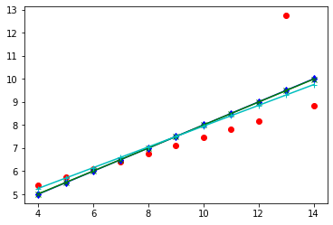

```python
dfreg = dfa3.sort_values('x', ascending = True).reset_index(drop=True)
X_vals = dfreg.iloc[:,1].values.reshape(-1,1)
y_vals = dfreg.iloc[:,2].values.reshape(-1,1)

# standard (usual) regression
reg_usual = linear_model.LinearRegression()
reg_usual.fit(X_vals, y_vals)
# Make predictions
y_pred_usual = reg_usual.predict(X_vals)
print('reg_usual_coef_ = ', reg_usual.coef_)
print('reg_usual_intercept_ = ', reg_usual.intercept_)

# ridge regression
reg_ridge = linear_model.Ridge(alpha=0.5)
reg_ridge.fit(X_vals, y_vals)
# Make predictions
y_pred_ridge = reg_ridge.predict(X_vals)
print('reg_ridge_coef_ = ', reg_ridge.coef_)
print('reg_ridge_intercept_ = ', reg_ridge.intercept_)

# LASSO regression
reg_lasso = linear_model.Lasso(alpha=0.5)
reg_lasso.fit(X_vals, y_vals)
# Make predictions
y_pred_lasso = reg_lasso.predict(X_vals)
print('reg_lasso_coef_ = ', reg_lasso.coef_)
print('reg_lasso_intercept_ = ', reg_lasso.intercept_)

plt.plot(X_vals,y_vals,'.r',marker='o')
plt.plot(X_vals,y_pred_usual,'b',marker='d')
plt.plot(X_vals,y_pred_ridge,'g',marker='x')
plt.plot(X_vals,y_pred_lasso,'c',marker='+')
```

### Solution 7

An outline solution to Exercise 7 follows.

```
reg_usual_coef_ =  [[0.49990909]]
reg_usual_intercept_ =  [3.00172727]
reg_ridge_coef_ =  [[0.49764706]]
reg_ridge_intercept_ =  [3.02208556]
reg_lasso_coef_ =  [0.44990909]
reg_lasso_intercept_ =  [3.45172727]
```

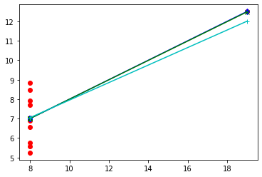

```python
dfreg = dfa4.sort_values('x', ascending = True).reset_index(drop=True)
X_vals = dfreg.iloc[:,1].values.reshape(-1,1)
y_vals = dfreg.iloc[:,2].values.reshape(-1,1)

# standard (usual) regression
reg_usual = linear_model.LinearRegression()
reg_usual.fit(X_vals, y_vals)
# Make predictions
y_pred_usual = reg_usual.predict(X_vals)
print('reg_usual_coef_ = ', reg_usual.coef_)
print('reg_usual_intercept_ = ', reg_usual.intercept_)

# ridge regression
reg_ridge = linear_model.Ridge(alpha=0.5)
reg_ridge.fit(X_vals, y_vals)
# Make predictions
y_pred_ridge = reg_ridge.predict(X_vals)
print('reg_ridge_coef_ = ', reg_ridge.coef_)
print('reg_ridge_intercept_ = ', reg_ridge.intercept_)

# LASSO regression
reg_lasso = linear_model.Lasso(alpha=0.5)
reg_lasso.fit(X_vals, y_vals)
# Make predictions
y_pred_lasso = reg_lasso.predict(X_vals)
print('reg_lasso_coef_ = ', reg_lasso.coef_)
print('reg_lasso_intercept_ = ', reg_lasso.intercept_)

plt.plot(X_vals,y_vals,'.r',marker='o')
plt.plot(X_vals,y_pred_usual,'b',marker='d')
plt.plot(X_vals,y_pred_ridge,'g',marker='x')
plt.plot(X_vals,y_pred_lasso,'c',marker='+')
```